# SIV Risk Factor Analysis: BinaryPLSR (PLS-DA)

jonasalexandersteiner

2025-08-13

# Research Question & Hypothesis

This report investigates predictors (risk factors) for SIV positivity in swine farms using BinaryPLSR (PLS-DA). The hypothesis is that farm-level management, animal contact, and biosecurity variables are associated with SIV status.

# PLS-DA Subset Analysis Overview

This report provides a separate PLS-DA analysis summary for each predictor subset:

- **Husbandry:** Farm management, biosecurity, and husbandry practices.
- **Animal Health:** Animal health status and performance.
- **Environment:** Environmental and housing conditions.
- **Human/Contact:** Human illness history and direct/indirect contacts.

## Husbandry Predictors

### Analysis Summary

- **Subset:** Husbandry
- **Sample Size:** 125
- **Predictors after filtering:** 118
- **Optimal number of components:** 1
- **Variance explained by each component:** 7.65, 7.5, 6.36 %
- **SIV Status Class Balance:**
  - Negative: 76 (60.8%)
  - Positive: 49 (39.2%)

### 1. PLS-DA Sample Scores Plot

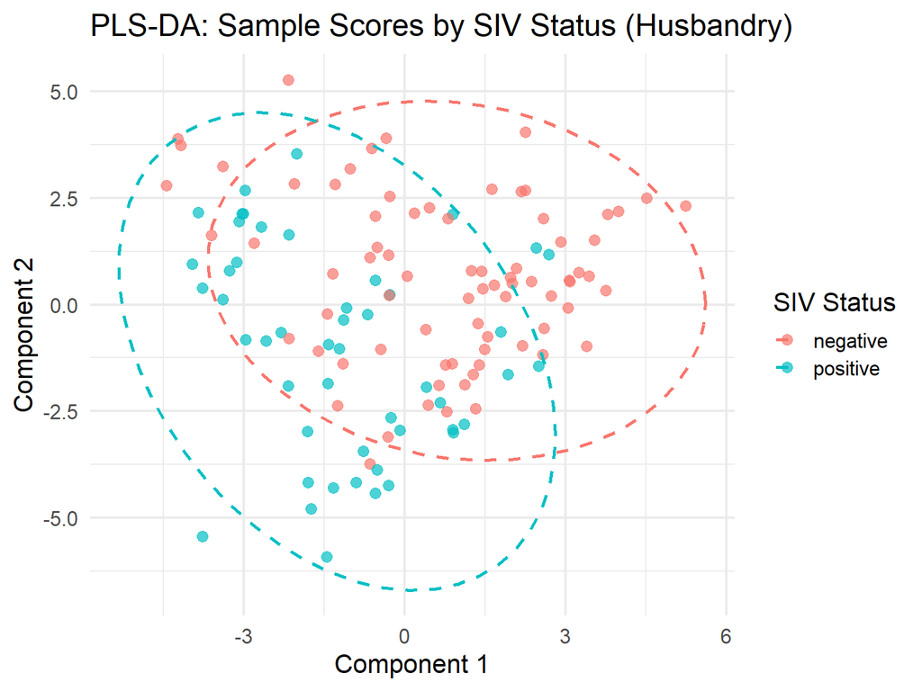

### 2. RMSEP Plot (Model Validation)

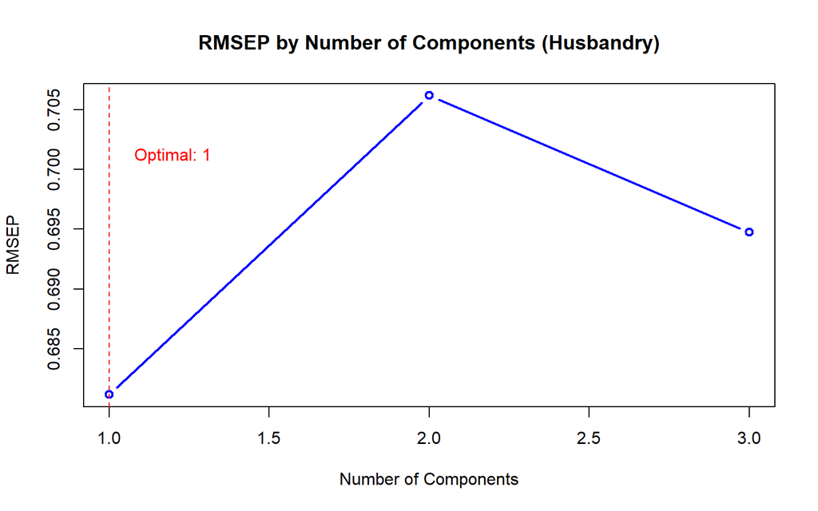

### 3. Risk and Protective Factors

#### Component 1 Risk/Protective Factors

|  | Predictor | Loading | Type |
| --- | --- | --- | --- |
| 1 | contact_bird_in_stable_TRUE | -0.2780789113223909 | Risk Factor |
| 2 | ai_airspace_with_other_agegroup_2 | -0.2493137799054853 | Risk Factor |
| 3 | cross_fostering_farrowing_stable_2 | 0.2347211630647035 | Protective Factor |
| 4 | caretaker_entry_ppe_only_TRUE | -0.1848252671961141 | Risk Factor |
| 5 | drying_farrowing_stable_TRUE | 0.1828786783966 | Protective Factor |
| 6 | outside_area_contact_wild_boars_TRUE | 0.1700330138628438 | Protective Factor |
| 7 | ai_airspace_with_other_agegroup_3 | 0.1661519488848263 | Protective Factor |
| 8 | production_type_factor_2 | 0.166151948884826 | Protective Factor |
| 9 | mode_stable_occupation_gestation_stable_TRUE | 0.162871476795575 | Protective Factor |
| 10 | fattening_pigs_airspace_with_other_agegroup_4 | 0.1421880205516856 | Protective Factor |

[output cut: 108 more lines]

#### Component 2 Risk/Protective Factors

|  | Predictor | Loading | Type |
| --- | --- | --- | --- |
| 1 | mode_stable_occupation_ai_centre_NA | 0.2357602568794276 | Protective Factor |
| 2 | mode_stable_occupation_fattening_stable_TRUE | 0.227574977566823 | Protective Factor |
| 3 | ai_airspace_with_other_agegroup_2 | -0.2161564147410341 | Risk Factor |
| 4 | outside_area_contact_wild_birds_TRUE | -0.1918234761520607 | Risk Factor |
| 5 | farrowing_airspace_with_other_agegroup_NA | 0.1751612500045981 | Protective Factor |
| 6 | disinfection_weaner_stable_1 | -0.1746272872513509 | Risk Factor |
| 7 | Weaners_on_farm_TRUE | -0.1739918279631889 | Risk Factor |
| 8 | mode_stable_occupation_ai_centre_TRUE | -0.1728569561635377 | Risk Factor |
| 9 | ai_airspace_with_other_agegroup_NA | 0.1708106941510157 | Protective Factor |
| 10 | production_cycle_3 | -0.16967697779972 | Risk Factor |

[output cut: 108 more lines]

#### Variable Importance in Projection (VIP) Scores

|  | Predictor | VIP Score |
| --- | --- | --- |
| 1 | contact_bird_in_stable_TRUE | 3.020710172927063 |
| 2 | ai_airspace_with_other_agegroup_2 | 2.70824086454469 |
| 3 | cross_fostering_farrowing_stable_2 | 2.549724471011086 |
| 4 | caretaker_entry_ppe_only_TRUE | 2.007716306778815 |
| 5 | drying_farrowing_stable_TRUE | 1.986570939943065 |
| 6 | outside_area_contact_wild_boars_TRUE | 1.847031305849275 |
| 7 | ai_airspace_with_other_agegroup_3 | 1.804872148920986 |
| 8 | production_type_factor_2 | 1.804872148920984 |
| 9 | mode_stable_occupation_gestation_stable_TRUE | 1.769237100707941 |
| 10 | fattening_pigs_airspace_with_other_agegroup_4 | 1.544557255731226 |

[output cut: 108 more lines]

### 4. Model Performance Summary

#### Confusion Matrix

Confusion Matrix

|  | FALSE | TRUE |
| --- | --- | --- |
| FALSE | 62 | 14 |
| TRUE | 23 | 26 |

#### Performance Metrics

Performance Metrics

| Metric | Value |
| --- | --- |
| Sensitivity | 0.531 |
| Specificity | 0.816 |
| Balanced Accuracy | 0.673 |
| AUC | 0.755 |

#### ROC Curve

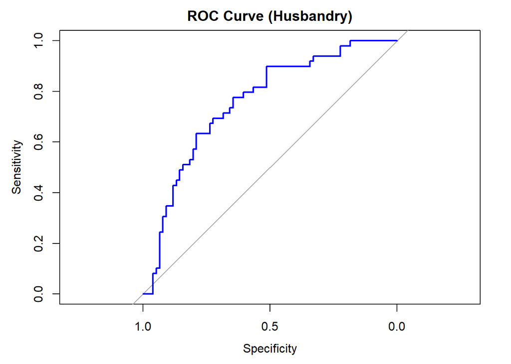

## Animal Health Predictors

### Analysis Summary

- **Subset:** Animal Health
- **Sample Size:** 125
- **Predictors after filtering:** 56
- **Optimal number of components:** 1
- **Variance explained by each component:** 14.46, 9.03, 3.7 %
- **SIV Status Class Balance:**
  - Negative: 76 (60.8%)
  - Positive: 49 (39.2%)

### 1. PLS-DA Sample Scores Plot

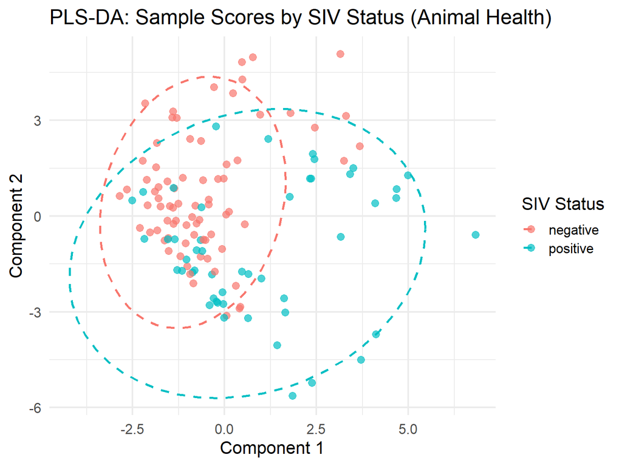

### 2. RMSEP Plot (Model Validation)

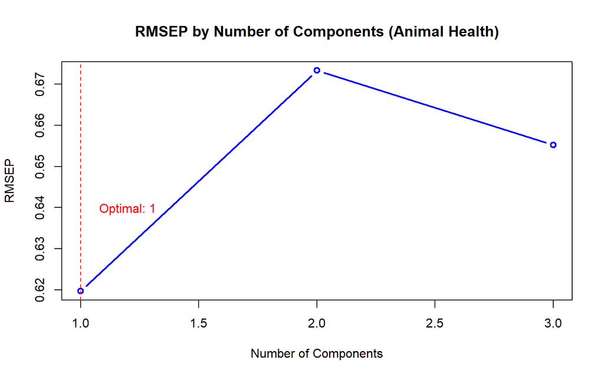

### 3. Risk and Protective Factors

#### Component 1 Risk/Protective Factors

|  | Predictor | Loading | Type |
| --- | --- | --- | --- |
| 1 | respiratory_history_swine_3 | 0.3923212603907745 | Risk Factor |
| 2 | farrowing_piglet_litters_sneezing_TRUE | -0.3222875405742592 | Protective Factor |
| 3 | symptom_swine_nasal_discharge_TRUE | 0.2749329611258182 | Risk Factor |
| 4 | symptomatic_report_TRUE | 0.2257236031545385 | Risk Factor |
| 5 | weaners_diseased_TRUE | 0.209700062275241 | Risk Factor |
| 6 | ili_signs_TRUE | 0.1990865755248301 | Risk Factor |
| 7 | symptom_swine_dyspnoea_TRUE | -0.1858415089926251 | Protective Factor |
| 8 | rectal_temperature_avg_&lt;40.0 | -0.184973243717216 | Protective Factor |
| 9 | symptom_swine_fever_TRUE | 0.1784516756005144 | Risk Factor |
| 10 | symptom_swine_coughing_TRUE | 0.1650135423801882 | Risk Factor |

[output cut: 46 more lines]

#### Component 2 Risk/Protective Factors

|  | Predictor | Loading | Type |
| --- | --- | --- | --- |
| 1 | piglets_per_sow_year_TRUE | -0.2913909097945744 | Risk Factor |
| 2 | farrowing_rate_TRUE | -0.2629253631444554 | Risk Factor |
| 3 | fattening_pigs_sneezing_NA | -0.2597060631726205 | Risk Factor |
| 4 | abortions_per_sow_year_TRUE | -0.2336645101324555 | Risk Factor |
| 5 | fattening_pigs_diseased_TRUE | 0.2135587696153199 | Protective Factor |
| 6 | symptom_swine_dyspnoea_TRUE | 0.209926434010928 | Protective Factor |
| 7 | weaners_sneezing_NA | 0.2097666829405181 | Protective Factor |
| 8 | return_to_service_rate_TRUE | -0.2054767957074206 | Risk Factor |
| 9 | piglet_mortality_TRUE | -0.1992722186527545 | Risk Factor |
| 10 | weaners_reduced_general_wellbeing_NA | 0.1896261895964274 | Protective Factor |

[output cut: 46 more lines]

#### Variable Importance in Projection (VIP) Scores

|  | Predictor | VIP Score |
| --- | --- | --- |
| 1 | respiratory_history_swine_3 | 2.935863483859208 |
| 2 | farrowing_piglet_litters_sneezing_TRUE | 2.411779113709766 |
| 3 | symptom_swine_nasal_discharge_TRUE | 2.057409889728101 |
| 4 | symptomatic_report_TRUE | 1.689160774224818 |
| 5 | weaners_diseased_TRUE | 1.569251574038222 |
| 6 | ili_signs_TRUE | 1.489827511840018 |
| 7 | symptom_swine_dyspnoea_TRUE | 1.390710509782943 |
| 8 | rectal_temperature_avg_&lt;40.0 | 1.384213007420116 |
| 9 | symptom_swine_fever_TRUE | 1.335410060385704 |
| 10 | symptom_swine_coughing_TRUE | 1.234848279529132 |

[output cut: 46 more lines]

### 4. Model Performance Summary

#### Confusion Matrix

Confusion Matrix

|  | FALSE | TRUE |
| --- | --- | --- |
| FALSE | 70 | 6 |
| TRUE | 28 | 21 |

#### Performance Metrics

Performance Metrics

| Metric | Value |
| --- | --- |
| Sensitivity | 0.429 |
| Specificity | 0.921 |
| Balanced Accuracy | 0.675 |
| AUC | 0.724 |

#### ROC Curve

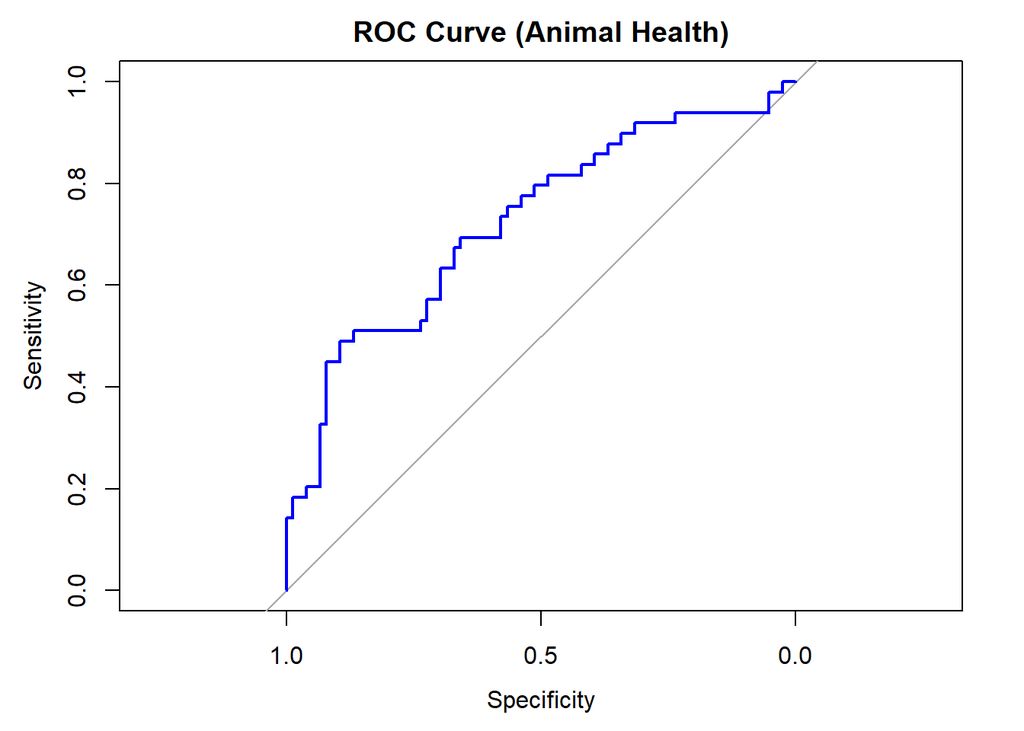

## Environment Predictors

### Analysis Summary

- **Subset:** Environment
- **Sample Size:** 125
- **Predictors after filtering:** 85
- **Optimal number of components:** 1
- **Variance explained by each component:** 10.71, 6.83, 3.49 %
- **SIV Status Class Balance:**
  - Negative: 76 (60.8%)
  - Positive: 49 (39.2%)

### 1. PLS-DA Sample Scores Plot

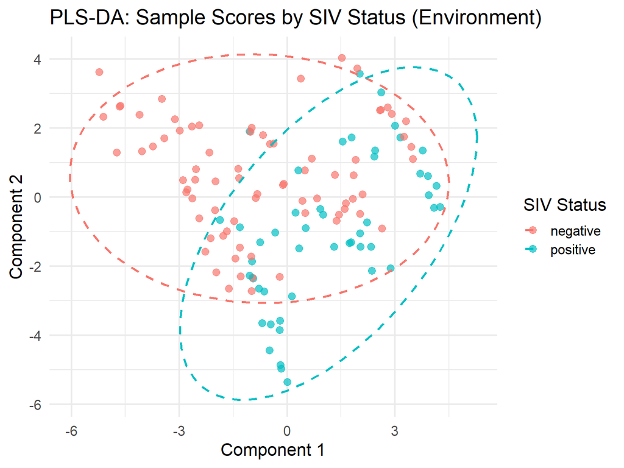

### 2. RMSEP Plot (Model Validation)

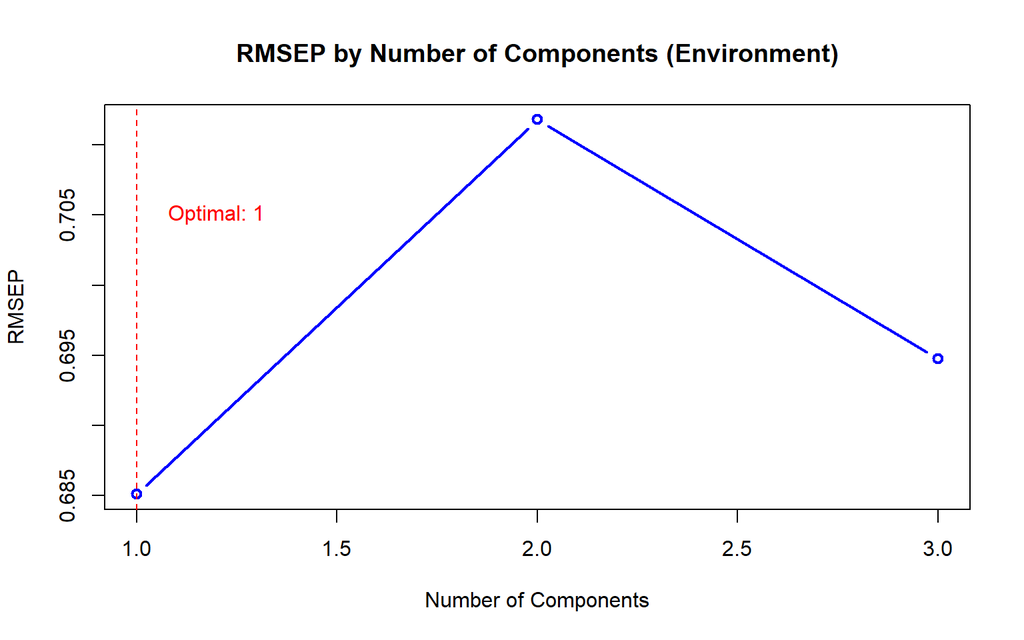

### 3. Risk and Protective Factors

#### Component 1 Risk/Protective Factors

|  | Predictor | Loading | Type |
| --- | --- | --- | --- |
| 1 | gestation_sows_airflow_NA | 0.2213795925892628 | Risk Factor |
| 2 | ai_sows_airflow_0.1–&lt;0.2 | -0.209641497054917 | Protective Factor |
| 3 | season_sampling_summer | -0.2095573933733343 | Protective Factor |
| 4 | ai_sows_room_temperature_&gt;=24 | -0.2095470649642313 | Protective Factor |
| 5 | gestation_sows_room_temperature_&gt;=25 | -0.2095470649642313 | Protective Factor |
| 6 | gestation_sows_airflow_&gt;=0.4 | -0.2052716904039468 | Protective Factor |
| 7 | weaners_animals_per_water_source_15–&lt;25 | -0.1965001005573431 | Protective Factor |
| 8 | weaners_room_temperature_NA | 0.1948259218980584 | Risk Factor |
| 9 | season_sampling_autumn | 0.1843600362828346 | Risk Factor |
| 10 | weaners_airflow_NA | 0.1843005480310574 | Risk Factor |

[output cut: 75 more lines]

#### Component 2 Risk/Protective Factors

|  | Predictor | Loading | Type |
| --- | --- | --- | --- |
| 1 | gestation_sows_room_temperature_17–&lt;21 | -0.237642220714234 | Risk Factor |
| 2 | farrowing_airflow_NA | 0.2328518908630151 | Protective Factor |
| 3 | ai_sows_airflow_NA | 0.2194663003440641 | Protective Factor |
| 4 | farrowing_room_temperature_NA | 0.210056366730197 | Protective Factor |
| 5 | ai_sows_airflow_0.2–&lt;0.4 | -0.199243254770342 | Risk Factor |
| 6 | farrowing_room_temperature_&lt;17 | -0.1934580186335794 | Risk Factor |
| 7 | farrowing_nest_temperature_ok_NA | 0.1914016390423401 | Protective Factor |
| 8 | gestation_sows_air_quality_NA | 0.1894224895494875 | Protective Factor |
| 9 | farrowing_nest_temperature_ok_TRUE | -0.1866535698114136 | Risk Factor |
| 10 | ai_sows_air_quality_3 | -0.1811962162060001 | Risk Factor |

[output cut: 75 more lines]

#### Variable Importance in Projection (VIP) Scores

|  | Predictor | VIP Score |
| --- | --- | --- |
| 1 | gestation_sows_airflow_NA | 2.041018995814096 |
| 2 | ai_sows_airflow_0.1–&lt;0.2 | 1.932799102191243 |
| 3 | season_sampling_summer | 1.932023704559869 |
| 4 | ai_sows_room_temperature_&gt;=24 | 1.931928481332971 |
| 5 | gestation_sows_room_temperature_&gt;=25 | 1.931928481332971 |
| 6 | gestation_sows_airflow_&gt;=0.4 | 1.89251147550285 |
| 7 | weaners_animals_per_water_source_15–&lt;25 | 1.811641412950948 |
| 8 | weaners_room_temperature_NA | 1.796206248372221 |
| 9 | season_sampling_autumn | 1.699715550657724 |
| 10 | weaners_airflow_NA | 1.699167096075777 |

[output cut: 75 more lines]

### 4. Model Performance Summary

#### Confusion Matrix

Confusion Matrix

|  | FALSE | TRUE |
| --- | --- | --- |
| FALSE | 55 | 21 |
| TRUE | 25 | 24 |

#### Performance Metrics

Performance Metrics

| Metric | Value |
| --- | --- |
| Sensitivity | 0.490 |
| Specificity | 0.724 |
| Balanced Accuracy | 0.607 |
| AUC | 0.742 |

#### ROC Curve

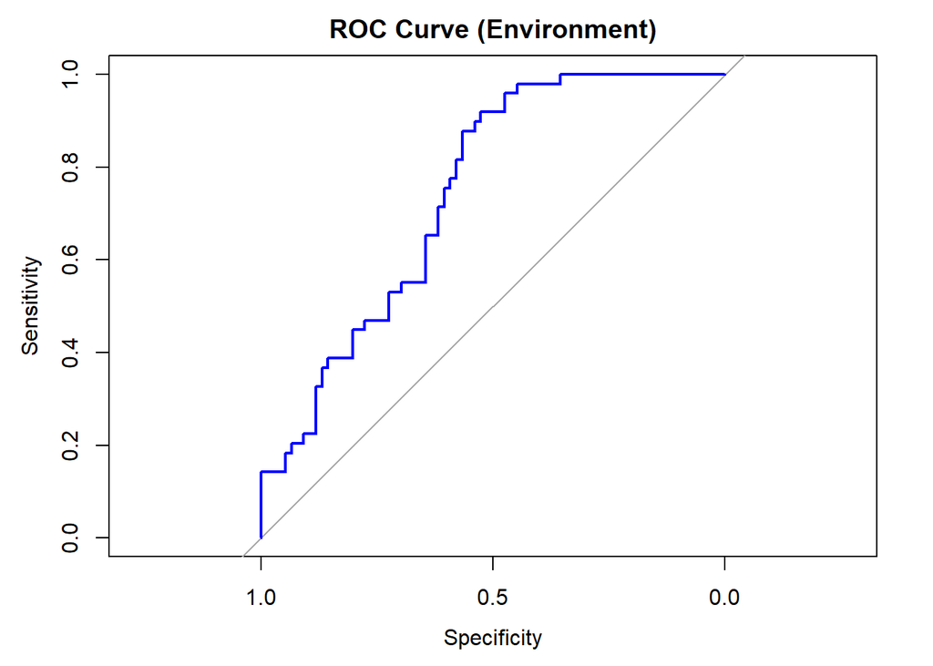

## Human/Contact Predictors

### Analysis Summary

- **Subset:** Human/Contact
- **Sample Size:** 125
- **Predictors after filtering:** 15
- **Optimal number of components:** 1
- **Variance explained by each component:** 26.15, 12.68, 5.85 %
- **SIV Status Class Balance:**
  - Negative: 76 (60.8%)
  - Positive: 49 (39.2%)

### 1. PLS-DA Sample Scores Plot

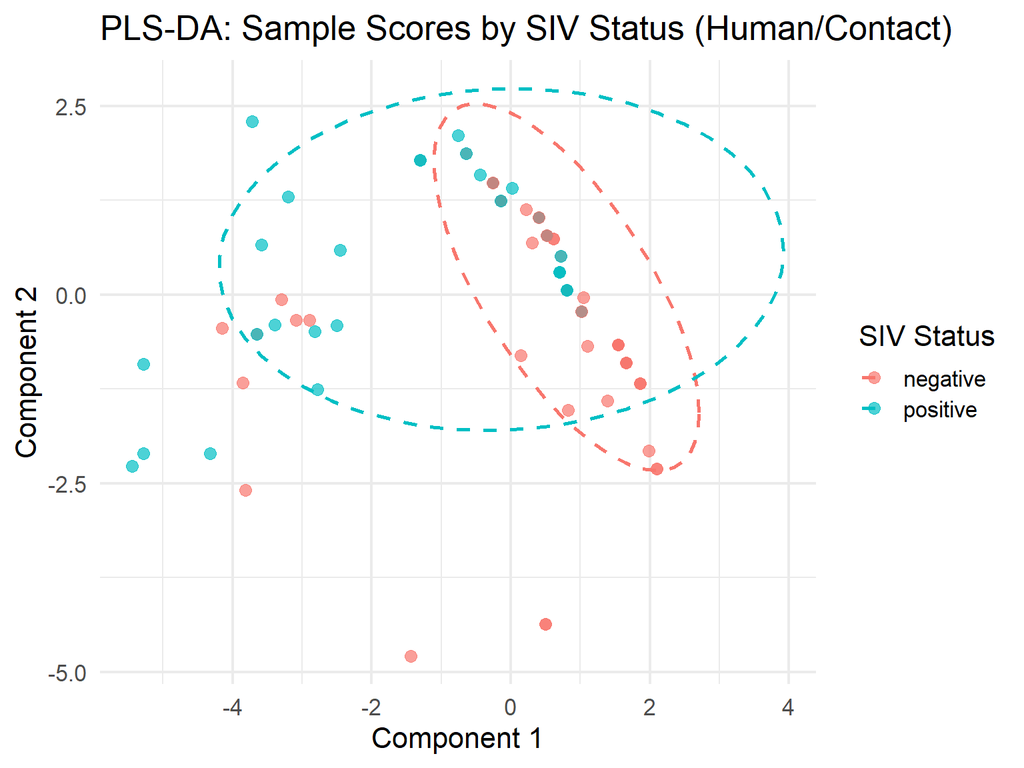

### 2. RMSEP Plot (Model Validation)

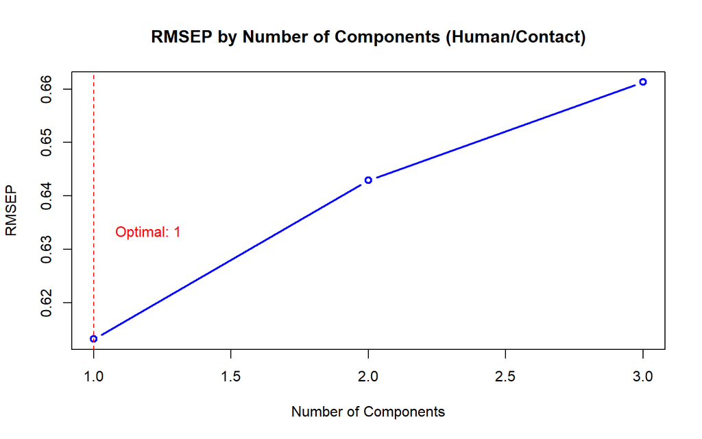

### 3. Risk and Protective Factors

#### Component 1 Risk/Protective Factors

|  | Predictor | Loading | Type |
| --- | --- | --- | --- |
| 1 | symptom_severity_NA | 0.4633651428036949 | Protective Factor |
| 2 | respiratory_history_human_TRUE | -0.4174032501132803 | Risk Factor |
| 3 | season_sampling_summer | 0.3929151684050135 | Protective Factor |
| 4 | symptom_human_coughing_TRUE | -0.3698214277956896 | Risk Factor |
| 5 | season_sampling_autumn | -0.3456707183514806 | Risk Factor |
| 6 | flu_vaccination_TRUE | 0.2497122012483815 | Protective Factor |
| 7 | respiratory_history_contact_person_TRUE | -0.2053381111097573 | Risk Factor |
| 8 | symptom_human_sneezing_TRUE | -0.1939668039643372 | Risk Factor |
| 9 | flu_vaccination_contacts_TRUE | -0.1578372806887769 | Risk Factor |
| 10 | symptom_human_fever_TRUE | -0.1162141805374837 | Risk Factor |

[output cut: 5 more lines]

#### Component 2 Risk/Protective Factors

|  | Predictor | Loading | Type |
| --- | --- | --- | --- |
| 1 | symptom_human_sneezing_TRUE | -0.5222636151418627 | Protective Factor |
| 2 | flu_vaccination_TRUE | -0.3634939315024741 | Protective Factor |
| 3 | respiratory_history_contact_person_TRUE | -0.3632588126774592 | Protective Factor |
| 4 | symptom_human_headache_TRUE | -0.3309009855331801 | Protective Factor |
| 5 | season_sampling_summer | -0.3165588937079896 | Protective Factor |
| 6 | symptom_human_fever_TRUE | -0.2855790824948363 | Protective Factor |
| 7 | symptom_human_coughing_TRUE | -0.2371234775350513 | Protective Factor |
| 8 | season_sampling_autumn | 0.2132598068226509 | Risk Factor |
| 9 | season_sampling_spring | 0.1812141176013365 | Risk Factor |
| 10 | flu_vaccination_contacts_TRUE | 0.122955756121873 | Risk Factor |

[output cut: 5 more lines]

#### Variable Importance in Projection (VIP) Scores

|  | Predictor | VIP Score |
| --- | --- | --- |
| 1 | symptom_severity_NA | 1.794605481291732 |
| 2 | respiratory_history_human_TRUE | 1.616595836341584 |
| 3 | season_sampling_summer | 1.5217539037049 |
| 4 | symptom_human_coughing_TRUE | 1.432312230923354 |
| 5 | season_sampling_autumn | 1.338776935446839 |
| 6 | flu_vaccination_TRUE | 0.9671311967797763 |
| 7 | respiratory_history_contact_person_TRUE | 0.7952710846697784 |
| 8 | symptom_human_sneezing_TRUE | 0.7512302014709566 |
| 9 | flu_vaccination_contacts_TRUE | 0.6113011595182986 |
| 10 | symptom_human_fever_TRUE | 0.4500955858148165 |

[output cut: 5 more lines]

### 4. Model Performance Summary

#### Confusion Matrix

Confusion Matrix

|  | FALSE | TRUE |
| --- | --- | --- |
| FALSE | 68 | 8 |
| TRUE | 36 | 13 |

#### Performance Metrics

Performance Metrics

| Metric | Value |
| --- | --- |
| Sensitivity | 0.265 |
| Specificity | 0.895 |
| Balanced Accuracy | 0.580 |
| AUC | 0.649 |

#### ROC Curve

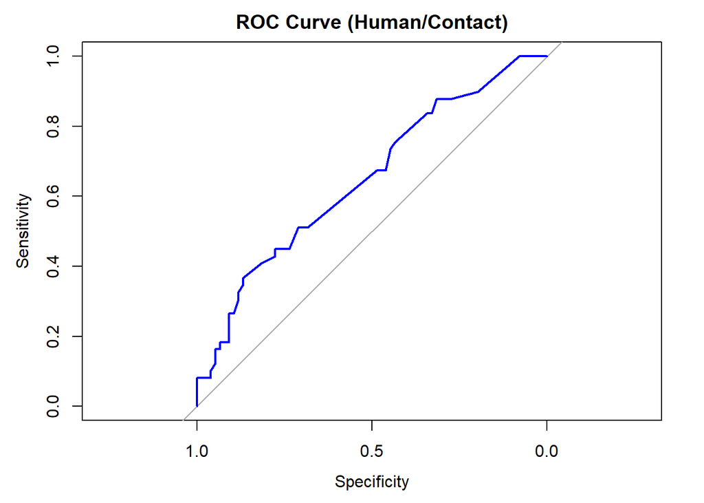

# Limitations

- Results depend on data preprocessing, filtering, and outcome coding (see logs for details).
- PLS-DA maximizes class separation rather than explained variance.
- Sample size and class imbalance may affect model stability.
- Component 2 may capture secondary patterns requiring further investigation.
- For very large datasets, further optimization (vectorized operations, data.table package) may be warranted.

# End of Report

If you have questions or wish to audit intermediate steps, please consult the logs and analysis script.